# Introducing the Tidyverse - Part 1

The Basics

# Cleaning Messy Data

In statistics classes, you are typically provided simple, clean datasets to load and analyze with ease. This is a terrible disservice to anyone who will deal with data outside of the classroom.

Anyone who works with data will have to do some data wrangling. Data wrangling is an appropriate description of cleaning, sorting, filtering, summarizing, transforming, and a whole host of other activities to make data usable for a specific purpose.

In this document, we introduce a moderately messy dataset and demonstrate basic programming commands to help us get data ready for analysis or visualization.

# The Tidyverse

All semester, we have been loading a library called `tidyverse`. Tidyverse is a library of libraries that provides a vast array of tools and a syntax that make wrangling data as simple as possible.

**NOTE**: Good scientists **NEVER** delete data from original records. The tidyverse allows us to create a new, clean dataset with a transparent set of steps from which we can create graphs and visualizations without losing any of the original data.

The `tidyverse` can be daunting to learn, but it is easier to demonstrate than to explain. We will work through several examples and have opportunities to practice.

## Additional Resources

Below are 2 great resources for digging a little deeper into data manipulation in R.

[Tidyverse Cheat Sheet](https://www.rstudio.com/wp-content/uploads/2015/02/data-wrangling-cheatsheet.pdf)

[R for Data Science](https://r4ds.had.co.nz/transform.html)

# Fundamentals

We will use a survey of high school students as our motivating example for cleaning data. Load the libraries and data in the code chunk below.

```r
# Load libraries and data

library(readxl)
library(rio)
library(mosaic)
library(tidyverse)
library(car)

survey <- import('https://github.com/byuistats/Math221D_Cannon/raw/master/Data/HighSchoolSeniors_subset.csv') %>% tibble()
```

## Logical Operators

Logical operators are used extensively in computer programming to determine if a certain condition is met. They always return a “True” or a “False”, but we can treat them like a 0 for false and 1 for true.

We can tell a computer to determine a conditional statement (typically “less than”, “greater than” or “not equal to”) for specific variables, and it will return a `TRUE` if the statement is true and `FALSE` if not.

### Quantitative Variables

Let’s examine the height_cm column in the survey data.

```r
favstats(survey$Height_cm)
```

```
  min  Q1 median      Q3 max     mean       sd   n missing
 1.68 161    170 178.125 999 169.2412 53.54382 312       0
```

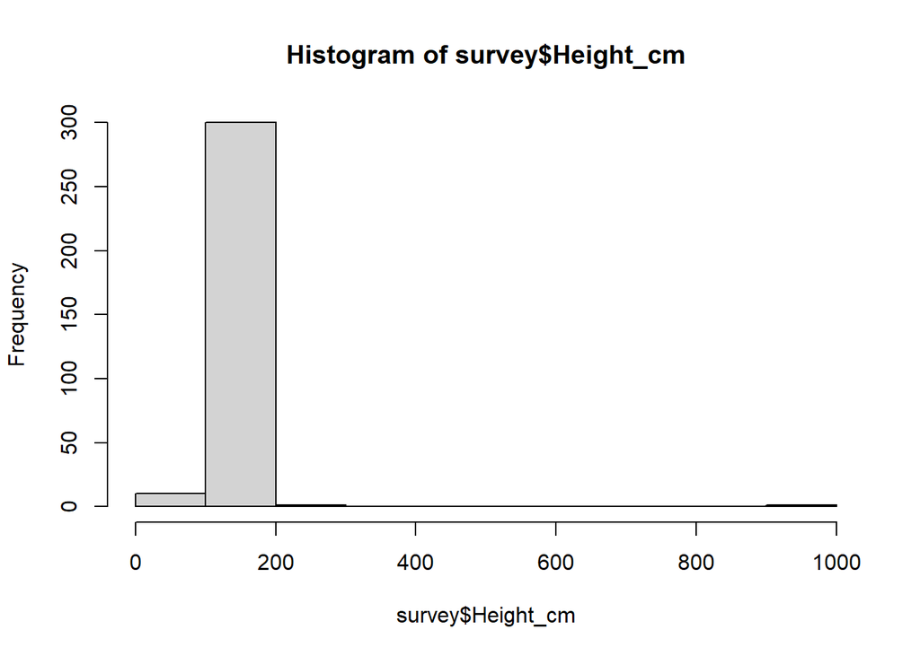

```r
hist(survey$Height_cm)
```

The maximum is 999 cm, which is around 33 Feet! We know this is not a possible value.

It is very unlikely that a high school student is taller than 7 feet. We can use a logical operator to see which students are taller than 7 feet (213.36 cm):

```r
survey$Height_cm > 213.36
```

```
  [1] FALSE FALSE FALSE FALSE FALSE FALSE FALSE FALSE FALSE FALSE FALSE FALSE
 [13] FALSE FALSE FALSE FALSE FALSE FALSE FALSE FALSE FALSE FALSE FALSE FALSE
 [25] FALSE FALSE FALSE FALSE FALSE FALSE FALSE FALSE FALSE FALSE FALSE FALSE
 [37] FALSE FALSE FALSE FALSE FALSE FALSE FALSE FALSE FALSE FALSE FALSE FALSE
 [49] FALSE FALSE FALSE FALSE FALSE FALSE FALSE FALSE FALSE FALSE FALSE FALSE
 [61] FALSE FALSE FALSE FALSE FALSE FALSE FALSE FALSE FALSE FALSE FALSE FALSE
 [73] FALSE FALSE FALSE FALSE FALSE FALSE FALSE FALSE FALSE FALSE  TRUE FALSE
 [85] FALSE FALSE FALSE FALSE FALSE FALSE FALSE FALSE FALSE FALSE FALSE FALSE
 [97] FALSE FALSE FALSE FALSE FALSE FALSE FALSE FALSE FALSE FALSE FALSE FALSE
[109] FALSE FALSE FALSE FALSE FALSE FALSE FALSE FALSE FALSE FALSE FALSE FALSE
[121] FALSE FALSE FALSE FALSE FALSE FALSE FALSE FALSE FALSE FALSE FALSE FALSE
[133] FALSE FALSE FALSE FALSE FALSE FALSE FALSE FALSE FALSE FALSE FALSE FALSE
[145] FALSE FALSE FALSE FALSE FALSE FALSE FALSE FALSE FALSE FALSE FALSE FALSE
[157] FALSE FALSE FALSE FALSE FALSE FALSE FALSE FALSE FALSE FALSE FALSE FALSE
[169] FALSE FALSE FALSE FALSE FALSE FALSE FALSE FALSE FALSE FALSE FALSE FALSE
[181] FALSE FALSE FALSE FALSE FALSE FALSE FALSE FALSE FALSE FALSE FALSE FALSE
[193] FALSE FALSE  TRUE FALSE FALSE FALSE FALSE FALSE FALSE FALSE FALSE FALSE
[205] FALSE FALSE FALSE FALSE FALSE FALSE FALSE FALSE FALSE FALSE FALSE FALSE
[217] FALSE FALSE FALSE FALSE FALSE FALSE FALSE FALSE FALSE FALSE FALSE FALSE
[229] FALSE FALSE FALSE FALSE FALSE FALSE FALSE FALSE FALSE FALSE FALSE FALSE
[241] FALSE FALSE FALSE FALSE FALSE FALSE FALSE FALSE FALSE FALSE FALSE FALSE
[253] FALSE FALSE FALSE FALSE FALSE FALSE FALSE FALSE FALSE FALSE FALSE FALSE
[265] FALSE FALSE FALSE FALSE FALSE FALSE FALSE FALSE FALSE FALSE FALSE FALSE
[277] FALSE FALSE FALSE FALSE FALSE FALSE FALSE FALSE FALSE FALSE FALSE FALSE
[289] FALSE FALSE FALSE FALSE FALSE FALSE FALSE FALSE FALSE FALSE FALSE FALSE
[301] FALSE FALSE FALSE FALSE FALSE FALSE FALSE FALSE FALSE FALSE FALSE FALSE
```

```r
# To illustrate, the below code puts the Survey column, Height_cm, along with the TRUE/FALSE logical
data.frame(Height_cm =survey$Height_cm, logical = survey$Height_cm > 213.36)[73:84,]
```

```
   Height_cm logical
73     162.0   FALSE
74     172.0   FALSE
75     160.0   FALSE
76     175.0   FALSE
77     182.8   FALSE
78     153.0   FALSE
79     184.0   FALSE
80     170.0   FALSE
81     150.0   FALSE
82     177.8   FALSE
83     999.0    TRUE
84     172.7   FALSE
```

What does the above code return?

A list of `TRUE` and `FALSE` for every line of the data. It is as long as the number of rows in the dataset.

### Categorical Variables

We can also use logical operators for categorical data. For example, if we wanted to see how many people are ambidextrous, we can run the following:

```r
# What are unique values in of the respondents?

unique(survey$Handed)
```

```
[1] "Left-Handed"  "Right-Handed" "Ambidextrous"
```

```r
# Use a logical operator to get TRUE and FALSE for students who responded "Ambidextrous" on the survey question about handedness

sum(survey$Handed == "Ambidextrous")
```

```
[1] 9
```

```r
data.frame(Handed = survey$Handed, logical = survey$Handed == 'Ambidextrous')
```

```
          Handed logical
1    Left-Handed   FALSE
2   Right-Handed   FALSE
3   Right-Handed   FALSE
4   Right-Handed   FALSE
5    Left-Handed   FALSE
6   Right-Handed   FALSE
7   Ambidextrous    TRUE
8   Right-Handed   FALSE
9   Right-Handed   FALSE
10  Right-Handed   FALSE
11  Right-Handed   FALSE
12   Left-Handed   FALSE
13  Right-Handed   FALSE
14  Right-Handed   FALSE
```

[output cut: 298 more lines]

We will show you why this is useful when we introduce tidyverse functions.

## Ceci n’est pas une pipe

The tidyverse organizes actions to data sequentially. We separate steps by what is called a “pipe” which is programmed `%>%`.

**HINT**: The shortkey for adding a “pipe” is `ctrl+shift+m` for Windows, and `cmd+shift+m` on Mac. Learn this because we use them a lot!

# Basic Tidyverse Functions

The most frequently used actions used for wrangling data are:

1. **Filtering rows** - eliminate rows based on certain criteria (logical operators)
2. **Selecting columns** - narrow the dataset to the specific *columns* required for the analysis or visualization
3. **Creating new columns** - create new columns based on the provided data. This could be as simple as changing a height from inches to centimeters.
4. **Summarizing data** - create customized data summaries, often by specific groups

You have already used `favstats()` to do (4) above, but we’ll learn how to do so with more flexibility with the tidyverse.

## Removing Rows - `filter()`

Logical operators are useful when removing rows from a dataset. The most common logical operators used to filter rows are:

- `<` and `<=` means “less than” and “less than or equal to” respectively
- `>` and `>=` means “greater than” and “greater than or equal to” respectively
- `==` means “equal to” (NOTE: we use double equals because in most computer languages, a single `=` is an assignment operator. This avoids ambiguity)
- `!=` means “not equal to”; this one is useful if you want to eliminate one level of a variable
- `%in%` is useful for defining a list of levels that you want to include

We typically begin with the raw dataset, then “pipe” that dataset into a sequence of functions using the “pipe” operator, `%>%`.

Let’s begin by filtering out rows we think have legitimate heights:

```r
survey %>%
  filter(Height_cm < 214)
```

```
# A tibble: 310 × 60
   Country Region DataYear ClassGrade Gender Ageyears Handed       Height_cm
   <chr>   <chr>     <int>      <int> <chr>     <dbl> <chr>            <dbl>
 1 USA     FL         2022         12 Male         18 Left-Handed        182
 2 USA     IN         2022         12 Male         17 Right-Handed       190
 3 USA     GA         2022         12 Female       17 Right-Handed       172
 4 USA     NC         2022         11 Female       15 Right-Handed       163
 5 USA     CO         2022         12 Female       17 Left-Handed         51
 6 USA     MO         2022         11 Male         17 Right-Handed       181
 7 USA     NC         2022         11 Male         17 Ambidextrous       175
 8 USA     SC         2022         11 Female       18 Right-Handed       160
 9 USA     WA         2022         11 Female       16 Right-Handed       156
10 USA     WA         2022         12 Female       17 Right-Handed       169
# ℹ 300 more rows
# ℹ 52 more variables: Footlength_cm <dbl>, Armspan_cm <dbl>,
#   Languages_spoken <dbl>, Travel_to_School <chr>,
#   Travel_time_to_School <int>, Reaction_time <dbl>,
#   Score_in_memory_game <dbl>, Favourite_physical_activity <chr>,
#   Imprtance_reducing_pllutin <int>, Imprtance_recycling_rubbish <int>,
#   Imprtance_cnserving_water <int>, Imprtance_saving_energy <int>, …
```

The above code will return a new dataset without the outliers.

How many rows does the original dataset have?

How many rows does the filtered dataset have?

Suppose for some reason, we only want to include right- or left-handed people (excluding ambidextrous). We can add multiple conditions in the `filter()` function separated by a comma:

```r
unique(survey$Handed)
```

```
[1] "Left-Handed"  "Right-Handed" "Ambidextrous"
```

```r
survey %>%
  filter(Height_cm < 214,
         Handed != "Ambidextrous")
```

```
# A tibble: 302 × 60
   Country Region DataYear ClassGrade Gender Ageyears Handed       Height_cm
   <chr>   <chr>     <int>      <int> <chr>     <dbl> <chr>            <dbl>
 1 USA     FL         2022         12 Male         18 Left-Handed        182
 2 USA     IN         2022         12 Male         17 Right-Handed       190
 3 USA     GA         2022         12 Female       17 Right-Handed       172
 4 USA     NC         2022         11 Female       15 Right-Handed       163
 5 USA     CO         2022         12 Female       17 Left-Handed         51
 6 USA     MO         2022         11 Male         17 Right-Handed       181
 7 USA     SC         2022         11 Female       18 Right-Handed       160
 8 USA     WA         2022         11 Female       16 Right-Handed       156
 9 USA     WA         2022         12 Female       17 Right-Handed       169
10 USA     WA         2022         11 Male         18 Right-Handed       160
# ℹ 292 more rows
# ℹ 52 more variables: Footlength_cm <dbl>, Armspan_cm <dbl>,
#   Languages_spoken <dbl>, Travel_to_School <chr>,
#   Travel_time_to_School <int>, Reaction_time <dbl>,
#   Score_in_memory_game <dbl>, Favourite_physical_activity <chr>,
#   Imprtance_reducing_pllutin <int>, Imprtance_recycling_rubbish <int>,
#   Imprtance_cnserving_water <int>, Imprtance_saving_energy <int>, …
```

```r
# Equivalently we can use %in% instead of the !=

survey %>%
  filter(Height_cm < 214,
         Handed %in% c("Left-Handed", "Right-Handed"),
         Region %in% c("MO", "FL"))
```

```
# A tibble: 27 × 60
   Country Region DataYear ClassGrade Gender Ageyears Handed       Height_cm
   <chr>   <chr>     <int>      <int> <chr>     <dbl> <chr>            <dbl>
 1 USA     FL         2022         12 Male         18 Left-Handed       182
 2 USA     MO         2022         11 Male         17 Right-Handed      181
 3 USA     MO         2022         11 Female       17 Right-Handed      151
 4 USA     FL         2022         12 Female       18 Right-Handed      170
 5 USA     FL         2022         12 Male         18 Right-Handed      180
 6 USA     FL         2022         12 Female       18 Right-Handed      173.
 7 USA     FL         2022         12 Male         18 Right-Handed      175
 8 USA     FL         2022         12 Male         17 Right-Handed      180
 9 USA     MO         2022         11 Male         17 Right-Handed      164
10 USA     FL         2022         12 Female       17 Right-Handed      166
# ℹ 17 more rows
# ℹ 52 more variables: Footlength_cm <dbl>, Armspan_cm <dbl>,
#   Languages_spoken <dbl>, Travel_to_School <chr>,
#   Travel_time_to_School <int>, Reaction_time <dbl>,
#   Score_in_memory_game <dbl>, Favourite_physical_activity <chr>,
#   Imprtance_reducing_pllutin <int>, Imprtance_recycling_rubbish <int>,
#   Imprtance_cnserving_water <int>, Imprtance_saving_energy <int>, …
```

```r
survey$Handed %in% c("Left-Handed", "Right-Handed")
```

```
  [1]  TRUE  TRUE  TRUE  TRUE  TRUE  TRUE FALSE  TRUE  TRUE  TRUE  TRUE  TRUE
 [13]  TRUE  TRUE  TRUE  TRUE  TRUE  TRUE  TRUE  TRUE  TRUE  TRUE  TRUE  TRUE
 [25]  TRUE  TRUE  TRUE FALSE  TRUE  TRUE  TRUE  TRUE  TRUE  TRUE  TRUE  TRUE
 [37]  TRUE  TRUE  TRUE  TRUE  TRUE  TRUE  TRUE  TRUE  TRUE  TRUE  TRUE FALSE
 [49]  TRUE  TRUE  TRUE  TRUE  TRUE  TRUE  TRUE  TRUE  TRUE  TRUE  TRUE  TRUE
 [61]  TRUE  TRUE  TRUE  TRUE  TRUE  TRUE  TRUE  TRUE  TRUE  TRUE  TRUE  TRUE
 [73]  TRUE  TRUE  TRUE  TRUE  TRUE  TRUE  TRUE  TRUE  TRUE  TRUE FALSE  TRUE
 [85]  TRUE  TRUE  TRUE  TRUE  TRUE  TRUE  TRUE  TRUE  TRUE  TRUE  TRUE  TRUE
 [97]  TRUE  TRUE  TRUE  TRUE  TRUE  TRUE  TRUE  TRUE  TRUE  TRUE  TRUE  TRUE
[109]  TRUE  TRUE  TRUE  TRUE  TRUE  TRUE  TRUE  TRUE  TRUE  TRUE  TRUE  TRUE
[121]  TRUE  TRUE  TRUE  TRUE  TRUE  TRUE  TRUE  TRUE  TRUE  TRUE  TRUE  TRUE
[133]  TRUE  TRUE  TRUE  TRUE  TRUE  TRUE  TRUE  TRUE  TRUE  TRUE FALSE  TRUE
[145]  TRUE  TRUE  TRUE  TRUE  TRUE  TRUE  TRUE  TRUE  TRUE  TRUE  TRUE  TRUE
[157]  TRUE  TRUE  TRUE  TRUE  TRUE  TRUE  TRUE  TRUE  TRUE  TRUE  TRUE  TRUE
[169]  TRUE  TRUE  TRUE  TRUE  TRUE  TRUE  TRUE  TRUE  TRUE  TRUE  TRUE  TRUE
[181]  TRUE  TRUE  TRUE  TRUE FALSE  TRUE  TRUE  TRUE  TRUE  TRUE  TRUE  TRUE
[193]  TRUE  TRUE  TRUE  TRUE  TRUE  TRUE  TRUE  TRUE  TRUE  TRUE  TRUE  TRUE
[205]  TRUE  TRUE FALSE  TRUE FALSE  TRUE  TRUE  TRUE  TRUE  TRUE  TRUE  TRUE
[217]  TRUE  TRUE  TRUE  TRUE  TRUE  TRUE  TRUE  TRUE  TRUE  TRUE  TRUE  TRUE
[229]  TRUE  TRUE  TRUE  TRUE  TRUE  TRUE  TRUE  TRUE  TRUE  TRUE  TRUE  TRUE
[241]  TRUE  TRUE  TRUE  TRUE  TRUE  TRUE  TRUE  TRUE  TRUE  TRUE  TRUE  TRUE
[253]  TRUE  TRUE  TRUE  TRUE  TRUE  TRUE  TRUE  TRUE  TRUE  TRUE  TRUE  TRUE
[265]  TRUE  TRUE  TRUE  TRUE  TRUE  TRUE  TRUE  TRUE  TRUE  TRUE  TRUE  TRUE
[277]  TRUE  TRUE  TRUE  TRUE  TRUE  TRUE  TRUE  TRUE  TRUE  TRUE  TRUE FALSE
[289]  TRUE  TRUE  TRUE  TRUE  TRUE  TRUE  TRUE  TRUE  TRUE  TRUE  TRUE  TRUE
[301]  TRUE  TRUE  TRUE  TRUE  TRUE  TRUE  TRUE  TRUE  TRUE  TRUE  TRUE  TRUE
```

How many rows does our latest dataset have?

## Adding Columns - `mutate()`

The `mutate()` statement is used to add new columns to a dataset.

To create a new column, “pipe” the previous steps into the `mutate()` statement. Inside the parentheses, give the new column a name and set it equal to what you want that column to be.

EXAMPLE: Create a column of the ratio of Height to armspan called, ht_to_span, by using a `mutate()` statement:

```r
clean <- survey %>%
  filter(Height_cm < 214,
         Handed != "Ambidextrous") %>%
  mutate(ht_to_span = Height_cm / Armspan_cm,
         ht_in = Height_cm / 2.54) %>%
  select(Handed, ht_to_span, ht_in)

View(clean)
```

Notice we no longer have to use `$` to access specific columns! The tidyverse lives up to its name!

## Selecting Columns - `select()`

There are now over 60 columns in this dataset. Suppose we are only interested in reaction times and height-to-armspan ratio as they related to handedness. To tidy up the data even further, select only the columns we are interested in (Handed, Reaction_time, and ht_to_span):

```r
survey %>%
  filter(Height_cm < 214,
         Handed != "Ambidextrous") %>%
  mutate(ht_to_span = Height_cm / Armspan_cm) %>%
  select(Handed, Reaction_time, ht_to_span)
```

```
# A tibble: 302 × 3
   Handed       Reaction_time ht_to_span
   <chr>                <dbl>      <dbl>
 1 Left-Handed          0.349      1.28
 2 Right-Handed         0.358      0.990
 3 Right-Handed         0.447      1.03
 4 Right-Handed         0.438      1.02
 5 Left-Handed          0.542      0.981
 6 Right-Handed         0.428      0.968
 7 Right-Handed         0.427      1.01
 8 Right-Handed         0.412      1.10
 9 Right-Handed         0.346      1.04
10 Right-Handed         0.391      1
# ℹ 292 more rows
```

See how much we can do in just a few short, sequential lines of code? Let’s name out clean dataset, `clean`, and create a boxplot of reaction times comparing left and right handed students:

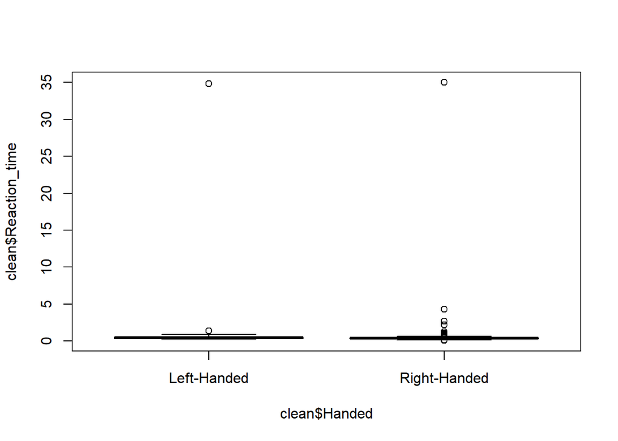

```r
clean <- survey %>%
  filter(Height_cm < 214,
         Handed != "Ambidextrous") %>%
  mutate(ht_to_span = Height_cm / Armspan_cm) %>%
  select(Handed, Reaction_time, ht_to_span)

boxplot(clean$Reaction_time ~ clean$Handed)

# Modify the code to remove outliers in Reaction_time and remake the boxplot

clean <- survey %>%
  filter(Height_cm < 214,
         Handed != "Ambidextrous") %>%
  mutate(ht_to_span = Height_cm / Armspan_cm) %>%
  select(Handed, Reaction_time, ht_to_span)

boxplot(clean$Reaction_time ~ clean$Handed)
```

## Summarising Data - `group_by()` + `summarise()`

The above data might be adequate for a visualization or analysis, but we can calculate summary statistics tables like we did with `favstats()` using the tidyverse.

The `summarise()` (or equivalently, `summarize()`) function is like the mutate statement. We create a name for the new column and set it equal to what we want.

Let’s name the new dataset, `clean`, and see how to make summaries using tidyverse.

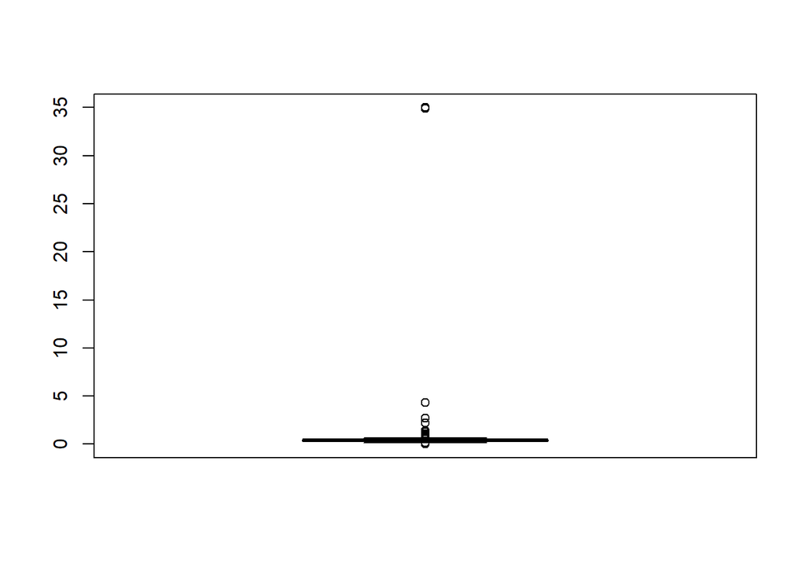

```r
boxplot(survey$Reaction_time)
```

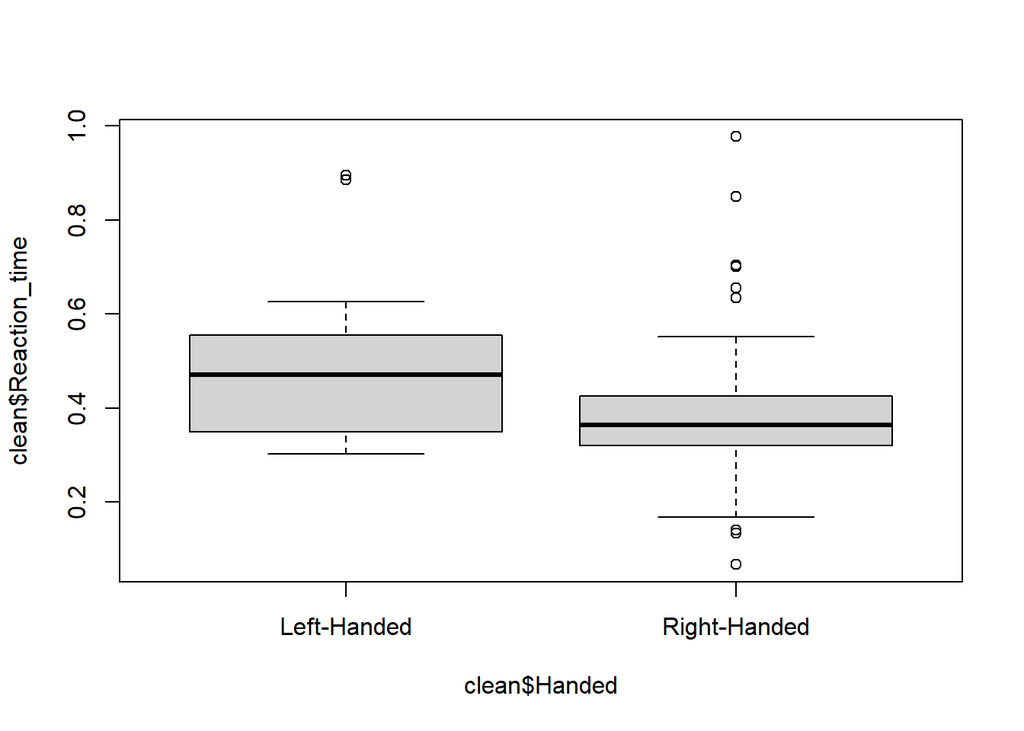

```r
clean <- survey %>%
  filter(Height_cm < 214,
         Handed != "Ambidextrous",
         Reaction_time < 1,
         Armspan_cm > 0,
         ClassGrade == 12) %>%
  mutate(ht_to_span = Height_cm / Armspan_cm) %>%
  select(Handed, Reaction_time, ht_to_span)

boxplot(clean$Reaction_time ~ clean$Handed)
```

```r
clean %>%
  summarise(
    mn_react_time = mean(Reaction_time, na.rm=TRUE),
    med_react_time = median(Reaction_time, na.rm=TRUE),
    mn_ratio = mean(ht_to_span, na.rm=TRUE)
  )
```

```
# A tibble: 1 × 3
  mn_react_time med_react_time mn_ratio
          <dbl>          <dbl>    <dbl>
1         0.397          0.366     1.27
```

Why might that be the case?

Modify the code chunk to exclude rows where arm span is 0:

```r
clean <- survey %>%
  filter(Height_cm < 214,
         Handed != "Ambidextrous",
         Reaction_time < 1) %>%
  mutate(ht_to_span = Height_cm / Armspan_cm) %>%
  select(Handed, Reaction_time, ht_to_span)



clean %>%
  summarise(
    `Mean Reaction Time` = mean(Reaction_time, na.rm=TRUE),
    med_react_time = median(Reaction_time, na.rm=TRUE),
    mn_ratio = mean(ht_to_span, na.rm=TRUE),
    min_react_time = min(Reaction_time, na.rm=TRUE)
  ) %>% knitr::kable()
```

| Mean Reaction Time | med_react_time | mn_ratio | min_react_time |
| --- | --- | --- | --- |
| 0.4205068 | 0.388 | Inf | 0.067 |

```r
favstats(clean$Reaction_time ~ clean$Handed)
```

```
  clean$Handed   min      Q1 median      Q3   max      mean        sd   n
1  Left-Handed 0.274 0.34825 0.4415 0.53850 0.895 0.4741471 0.1691585  34
2 Right-Handed 0.067 0.33825 0.3845 0.44775 0.995 0.4134380 0.1302318 258
  missing
1       0
2       0
```

```r
favstats(clean$ht_to_span)
```

```
    min        Q1   median       Q3 max mean  sd   n missing
 0.0168 0.9841579 1.006519 1.052681 Inf  Inf NaN 292       0
```

If we want to get means for separate groups, we can add a `group_by()` statement to tell which variable(s) we want to group by:

```r
clean <- survey %>%
  filter(Height_cm < 214,
         Handed != "Ambidextrous",
         Reaction_time < 1,
         Armspan_cm > 0) %>%
  mutate(ht_to_span = Height_cm / Armspan_cm) %>%
  select(Handed, Reaction_time, ht_to_span)



clean %>%
  group_by(Handed) %>%
  summarise(
    mn_react_time = mean(Reaction_time, na.rm=TRUE),
    med_react_time = median(Reaction_time, na.rm=TRUE),
    mn_ratio = mean(ht_to_span, na.rm=TRUE),
    max_react = max(Reaction_time),
    count = n()
  ) %>%
  knitr::kable()
```

| Handed | mn_react_time | med_react_time | mn_ratio | max_react | count |
| --- | --- | --- | --- | --- | --- |
| Left-Handed | 0.4741471 | 0.4415 | 1.266468 | 0.895 | 34 |
| Right-Handed | 0.4133891 | 0.3840 | 1.260190 | 0.995 | 257 |

The `n()` is very useful for counting up the number of observations in each group.

If we were only interested in the summary statistics table, we can do everything in one series of steps:

```r
summary_stats_table <-  survey %>%
  filter(
    Height_cm < 214,
    Handed != "Ambidextrous",
    Reaction_time < 1,
    Armspan_cm > 0) %>%
  mutate(ht_to_span = Height_cm / Armspan_cm) %>%
  select(Handed, Reaction_time, ht_to_span) %>%
  group_by(Handed) %>%
  summarise(
    mn_react_time = mean(Reaction_time, na.rm=TRUE),
    med_react_time = median(Reaction_time, na.rm=TRUE),
    mn_ratio = mean(ht_to_span, na.rm=TRUE),
    max_react = max(Reaction_time),
    count = n()
  )

summary_stats_table
```

```
# A tibble: 2 × 6
  Handed       mn_react_time med_react_time mn_ratio max_react count
  <chr>                <dbl>          <dbl>    <dbl>     <dbl> <int>
1 Left-Handed          0.474          0.442     1.27     0.895    34
2 Right-Handed         0.413          0.384     1.26     0.995   257
```

# Practice Together

Suppose we want to see who gets more sleep on non-school nights, males or females whose chosen superpower is telepathy.

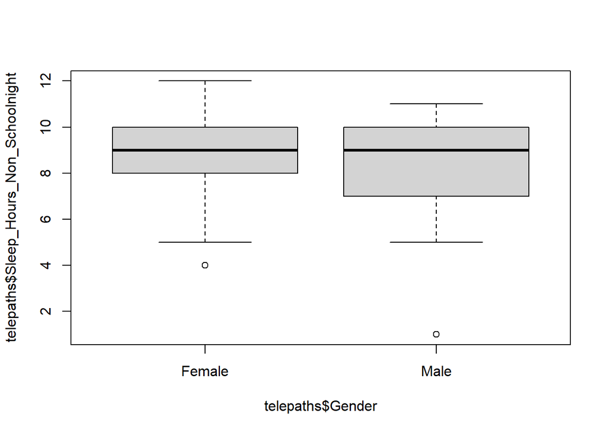

```r
telepaths <- survey %>%
  select(Gender, Sleep_Hours_Non_Schoolnight, Superpower) %>%
  filter(Superpower=="Telepathy")

boxplot(telepaths$Sleep_Hours_Non_Schoolnight ~ telepaths$Gender)
```

```r
telepaths %>%
  group_by(Gender) %>%
  summarise(
    mn_sleep_hours = mean(Sleep_Hours_Non_Schoolnight)
  ) %>%
  knitr::kable()
```

| Gender | mn_sleep_hours |
| --- | --- |
| Female | 8.733333 |
| Male | 8.190476 |

Also, create a column that is the ratio of sleep hours on non-school nights to 8. This calculates the percent of recommended sleep on non-school nights.

1. Create a dataset that includes columns Gender, Superpower, Sleep_Hours_Non-Schoolnight, and the ratio of non-schoolnight sleep hours divided by 8, for Males and Females who choose Telepathy as their superpower.
2. Create a summary table comparing males and females whose preferred super power is telepathy that includes:

```
a. Use `favstats()` to get the mean, median, standard deviation, and sample size of Sleep Hours on non-school nights
b. Use `group_by()` to get the mean, median, standard deviation, and sample size of the percent of recommended sleep
```

**HINT**: Use the `unique()` function to see what the options are for a given categorical variable.

```r
telepaths2 <- survey %>%
  mutate(
    sleep_ratio = Sleep_Hours_Non_Schoolnight / 8
  ) %>%
  select(Gender, Superpower, Sleep_Hours_Non_Schoolnight, sleep_ratio) %>%
  filter(Superpower == "Telepathy")

telepaths2 %>%
  group_by(Gender) %>%
  summarise(
    Mean_Ratio = mean(sleep_ratio),
    Median_Ratio = median(sleep_ratio),
    SD_Ratio = sd(sleep_ratio),
    Count = n()
  )
```

```
# A tibble: 2 × 5
  Gender Mean_Ratio Median_Ratio SD_Ratio Count
  <chr>       <dbl>        <dbl>    <dbl> <int>
1 Female       1.09         1.12    0.235    60
2 Male         1.02         1.12    0.295    21
```

```r
favstats(telepaths2$Sleep_Hours_Non_Schoolnight ~ telepaths2$Gender)[c("mean", "median", 'sd', 'n')]
```

```
      mean median       sd  n
1 8.733333      9 1.876407 60
2 8.190476      9 2.358369 21
```

# Your Turn

Use the above `tidyverse` functions to answer the following questions:

1. How many vegetarians say meat is their favorite food?

**HINT**: This can be done with a filter statement

2. Compare mean, median, and standard deviation of heights and the sample size between those who are vegetarian and those who aren’t.

Be sure to filter out any major outliers in heights first.

```r
unique(survey$Vegetarian)
```

```
[1] "No"  "Yes"
```

3. Create a dataset that:
   1. Includes a column that is *percent of recommended sleep* (Sleep_Hours_Schoolnight divided by 8 using a mutate statement)
   2. Includes only columns for Favourite_physical_activity, Reaction_time, percent_recommended_sleep (part a)
   3. Includes only students whose favorite physical activity is Walking/Hiking, Basketball, Swimming, Soccer
   4. Filters Reaction Times to be less than 1 second

Use the clean dataset to:

4. Create a side-by-side boxplot for the percent of recommended sleep for each favorite physical activity
5. Create a side-by-side boxplot for the reaction times for each favorite physical activity